# Resequencing analysis of Bacillus subtilis soil isolates

DUBii – Miniproject – Final examination Modules 4 & 5

Corinne Mhiri

2020-07-16

# Objectives

## 1. Creation of the project directory structure

The directory associed to this project has been named `bacillus` and stocked under `/shared/mfs/data/projects/dubii2020/cmhiri/projects/` in the IFB core cluster. Several subdirectories corresponding to the different analysis steps have been created.

```bash
project_home_path="/shared/mfs/data/projects/dubii2020/cmhiri/projects/bacillus"

#creation of the project directory structure on the IFB cluster
mkdir -p ${project_home_path}/reseq_strains
mkdir -p ${project_home_path}/ref_strain
mkdir -p ${project_home_path}/QC
mkdir -p ${project_home_path}/cleaning
mkdir -p ${project_home_path}/mapping
mkdir -p ${project_home_path}/reports
```

## 2. Data downloading

Data have been dowloaded by using the `wget`command for the *Bacillus subtilis* str 168 ([https://www.ncbi.nlm.nih.gov/assembly/GCF_000009045.1/]) reference genome (.fa and its associated .gff file ) with the -q option to inactivate command-related messages. The SRR10390685 run containing the sequenced *Bacillus* strain P5-B1 has been downloaded with the `fasterq-dump`tool from the `SRA-tools`module (version 2.10.3) available on the IFB cluster. The 2 dowloaded files (pair-ended) have been compressed with the `gzip`command. Here are the command used on the IBF cluster to dowload the data :

```bash
project_home_path="/shared/mfs/data/projects/dubii2020/cmhiri/projects/bacillus"

cd ${project_home_path}/ref_strain

wget -q https://ftp.ncbi.nlm.nih.gov/genomes/all/GCF/000/009/045/GCF_000009045.1_ASM904v1/GCF_000009045.1_ASM904v1_genomic.gff.gz
wget -q https://ftp.ncbi.nlm.nih.gov/genomes/all/GCF/000/009/045/GCF_000009045.1_ASM904v1/GCF_000009045.1_ASM904v1_genomic.fna.gz

cd ${project_home_path}/reseq_strains

module load sra-tools/2.10.3

srun fasterq-dump -S -p SRR10390685 --outdir . --threads 4
gzip *.fastq
```

## 3. Quality control of row reads

This step has been done by using the `fastqc`module (version 0.11.8) available at the IFB cluster. Resulting html reports have been downloaded locally for quality run analysis.

```bash
project_home_path="/shared/mfs/data/projects/dubii2020/cmhiri/projects/bacillus"

cd ${project_home_path}

module load fastqc/0.11.8
srun --cpus-per-task 8 fastqc reseq_strains/SRR10390685_1.fastq.gz -o QC/ -t 8
srun --cpus-per-task 8 fastqc reseq_strains/SRR10390685_2.fastq.gz -o QC/ -t 8
```

In the QC directory, two reports (SRR10390685_1_fastqc.html and SRR10390685_2_fastqc.html) have been produced and locally downloaded. The overall base quality looked good, with QC >20 for most bases except for some terminal ones

| Measure | Value | Value |
| --- | --- | --- |
| Filename | SRR10390685_2.fastq.gz | SRR10390685_1.fastq.gz |
| File type | Conventional base calls | Conventional base calls |
| Encoding | Sanger / Illumina 1.9 | Sanger / Illumina 1.9 |
| Total Sequences | 7066055 | 7066055 |
| Sequences flagged as poor quality | 0 | 0 |
| Sequence length | 130-151 | 34-151 |
| %GC | 43 | 43 |

As the total base number recovered from the SSR10390685 run was [2,119,142,216 bases](https://www.ncbi.nlm.nih.gov/Traces/study/?acc=SRX7091090&o=acc_s%3Aa) and the *Bacillus subtilis* str 168 reference genome is [4,215,606 bp long](https://www.ncbi.nlm.nih.gov/assembly/GCF_000009045.1/), **the sequencing depth equals appr. 500**. The length of the reference genome could also be retrieved with the `samtools faidx` command (in the second column)

## 4. Read cleaning

SSR10390685 reads have been cleaned by using the `fastp` tool (version 0.20.0). Default `fastp` parameters detect and remove classical Illumina adapter, filter reads with mean quality >=20 on a sliding window of 4, max allowed N in reads equal 5.The minimum length of the trimmed reads has been set to 100 bases (-l 100). Only an html report has been asked (-h) and a report title given (-R). Paired reads of good quality have been put in twin files (–out1 and –out2), singletons in separate files (–unpaired1 or –unpaired2) and poor quality reads in a –failed_out file.

```bash
###script fastp.bash in the 'scripts' directory

#!/bin/bash
#SBATCH --cpus-per-task=8

module load fastp/0.20.0

project_home_path="/shared/mfs/data/projects/dubii2020/cmhiri/projects/bacillus"
cd ${project_home_path}

srun --cpus-per-task 8 fastp \
  --in1 reseq_strains/SRR10390685_1.fastq.gz \
  --in2 reseq_strains/SRR10390685_2.fastq.gz \
  --out1 cleaning/SRR10390685_1_cleaned_filtered.fastq.gz \
  --out2 cleaning/SRR10390685_2_cleaned_filtered.fastq.gz \        --unpaired1 cleaning/SRR10390685_1_unpaired.fastq.gz \
  --unpaired2 cleaning/SRR10390685_2_unpaired.fastq.gz \
  --failed_out cleaning/SRR10390685_2_failed_out.fastq.gz \
  -h cleaning/SRR10390685_fastp.html\
  -R "Bacillus subtilis SRR10390685 fastp report" \
  --thread 1
```

Two cleaned (filtered) files corresponding to paired reads have been created in the ‘cleaning’ directory as well as an [SRR10390685_fastp.html report](https://rstudio.cluster.france-bioinformatique.fr/file_show?path=%2Fshared%2Fmfs%2Fdata%2Fprojects%2Fdubii2020%2Fcmhiri%2Fprojects%2Fbacillus%2Fcleaning%2FSRR10390685_fastp.html)

As given in the summary of the fastp.html report, **the pourcentage of filtered reads equals 2.6 %**, corresponding mainly to low quality reads (2.59%) and reads with too many N (0.03%).

## 5. Read mapping

Reads have been mapped on the *Bacillus* reference genome by using the `bwa`mapping tool (version 0.7.17) and the `samtools` tool (version 1.9) to convert the alignment file from .sam to .bam format . First a genome index has been created with the `bwa index`command and the alignment done with the `bwa mem`one. A script “bwa.bash” has been run to produce the output file SRR10390685.bam

```bash
#!/bin/bash

#SBATCH --cpus-per-task=8

module load bwa/0.7.17
module load samtools/1.9

DIR_HOME_PROJECT="/shared/mfs/data/projects/dubii2020/cmhiri/projects/bacillus"
DIR_CLEANED_READS="/shared/mfs/data/projects/dubii2020/cmhiri/projects/bacillus/cleaning"

cd ${DIR_HOME_PROJECT}

srun gunzip ref_strain/GCF_000009045.1_ASM904v1_genomic.fna.gz

srun bwa  index ref_strain/GCF_000009045.1_ASM904v1_genomic.fna

srun --cpus-per-task=8 bwa mem \
  ref_strain/GCF_000009045.1_ASM904v1_genomic.fna\
  ${DIR_CLEANED_READS}/SRR10390685_1_cleaned_filtered.fastq.gz \
  ${DIR_CLEANED_READS}/SRR10390685_2_cleaned_filtered.fastq.gz \
  -t 8 \
  |
  samtools view -hbS > mapping/SRR10390685.bam
```

The percentage of aligned paired-reads could be found by running the following script ‘samtools_index_stat.bash’ on the IFB cluster (script in bacillus/scripts directory), using the sorted SRR10390685.bam file and the `samtools flagstat`command:

```bash
srun samtools index SRR10390685_sorted.bam
srun samtools flagstat SRR10390685_sorted.bam
```

The output ‘slurm-9727706.out’ contained the following data :

```bash
13780340 + 0 in total (QC-passed reads + QC-failed reads)
0 + 0 secondary
18710 + 0 supplementary
0 + 0 duplicates
13025672 + 0 mapped (94.52% : N/A)
13761630 + 0 paired in sequencing
6880815 + 0 read1
6880815 + 0 read2
12943762 + 0 properly paired (94.06% : N/A)
12966884 + 0 with itself and mate mapped
40078 + 0 singletons (0.29% : N/A)
0 + 0 with mate mapped to a different chr
0 + 0 with mate mapped to a different chr (mapQ>=5)
```

The number of properly paired reads (= aligned paired reads) is **12,943,762** corresponding to **93.93% of total reads**.

## 6. Extraction of specific reads aligning at least 50% on the trmNF gene

First the line containing the coordinates of the trmNF gene has been extracted from the *Bacillus* .ggf3 file in a file called ‘trmNF_gene.gff’

```bash
grep "trmNF" ref_strain/GCF_000009045.1_ASM904v1_genomic.gff |awk '$3=="gene"' > reports/trmNF_gene.gff
```

Then the following script “trmNF.bash” has been written in the ’scripts’directory and run on the cluster :

```bash
#!/bin/bash

module load samtools/1.9
module load bedtools/2.27.1

DIR_HOME_PROJECT="/shared/mfs/data/projects/dubii2020/cmhiri/projects/bacillus"

cd ${DIR_HOME_PROJECT}


#use of bedtools intersect to extract from the SRR.bam file the reads mapping at least 50% to the trmNF gene

srun bedtools intersect -a mapping/SRR10390685_sorted.bam \
                        -b  reports/trmNF_gene.gff \
                        -f 0.5\
                         > reports/SSR10390685_trmNF_filtered_0.5.bam

#count the lines of the resulting .bam file and put the result into a variable called SSRtrmNF

SSRtrmNF=$(srun samtools view -c reports/SSR10390685_trmNF_filtered_0.5.bam)

echo ${SSRtrmNF}
echo "The read number overlapping at least 50% of the reference trmNF gene is: ${SSRtrmNF}"
```

Response (in the output ‘slurm-9732008.out’): 2844

The read number overlapping at least 50% of the reference trmNF gene is: **2844**

## Project Tree

The directory of the project ‘bacillus’ can be visualized with the `tree` command: `$ tree /shared/projects/dubii2020/cmhiri/projects/bacillus`

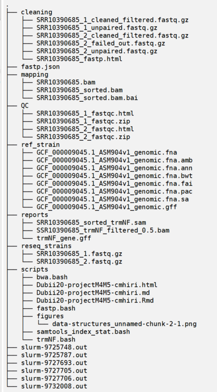

Tree caption from the bacillus directory